# Air Pollution

Statistical Case Study

Author

Affiliation

Leah Levensailor

Smith College

Published

January 2, 2026

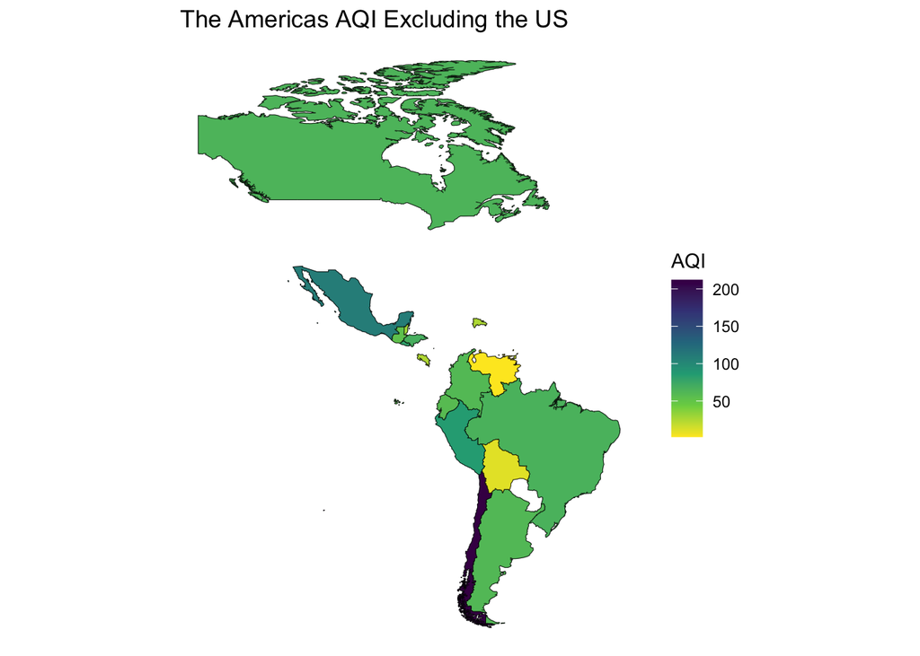

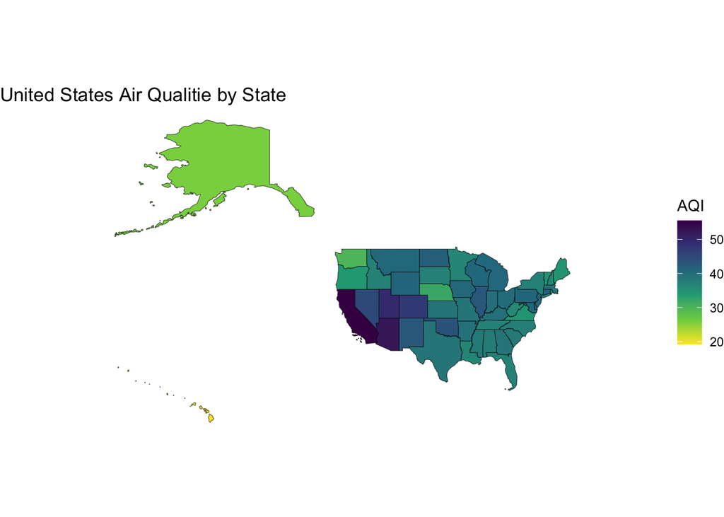

# Blog Post

## Introduction

Air pollution is a public health concern that countries all around the world need to take into consideration. Each country has a different way of reporting air pollution levels. According to [Wikipedia](https://en.wikipedia.org/wiki/Air_quality_index), the United States Environmental Protection Agency (EPA) created the Air Quality Index (AQI) that is based on the five pollutants: ground-level ozone, particulate matter, carbon monoxide, sulfur dioxide, and nitrogen dioxide. The six levels of public health concerns are pictured below.

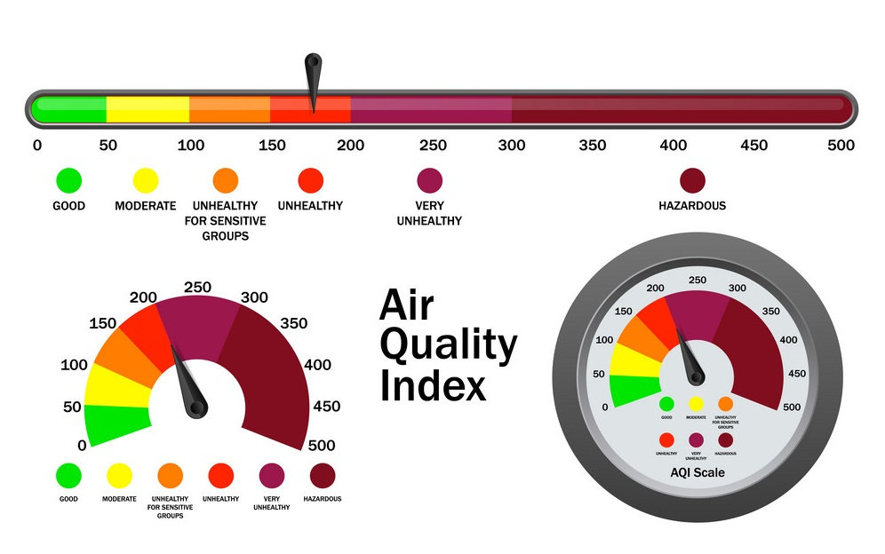

Air Quality Index

Several datasets were used in this project.

- The dataset containing AQI scores for the United States can be found [here](https://www.datapandas.org/ranking/air-quality-by-state)
- The dataset containing AQI scores for the rest of the world can be found [here](https://www.kaggle.com/datasets/azminetoushikwasi/aqi-air-quality-index-scheduled-daily-update)
- The dataset that Danielle used to map world countries can be found in the `wbstats` package in R. She figured out how to do this thanks to [this video](https://www.youtube.com/watch?v=KZcKv3HgzII) and found the boundary box coordinates using [this site](https://www.openstreetmap.org/export#map=3/47.75/7.91)
- The dataset that Leah used to map world countries were from the datasets from Project 2 and can be found [here](https://public.opendatasoft.com/explore/dataset/world-administrative-boundaries/export/?flg=en-us)
- The datasets that Zaixiao used to map world countries were the `countries` and `continents` datasets from Project 2 as well as a dataset that can be found [here](https://public.opendatasoft.com/explore/dataset/world-administrative-boundaries/export/?flg=en-us)

## AQI Scores in Asia & Oceania

Referencing map is Figure 1

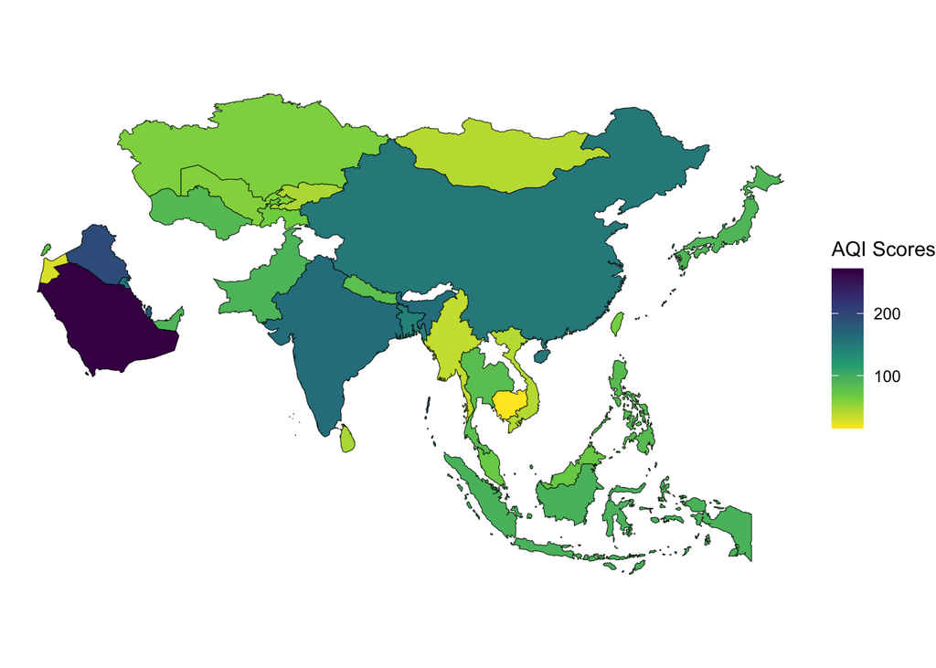

Figure 1: Map of AQI Scores in Asia

## AQI Scores in Europe

Referencing map in text is Figure 2

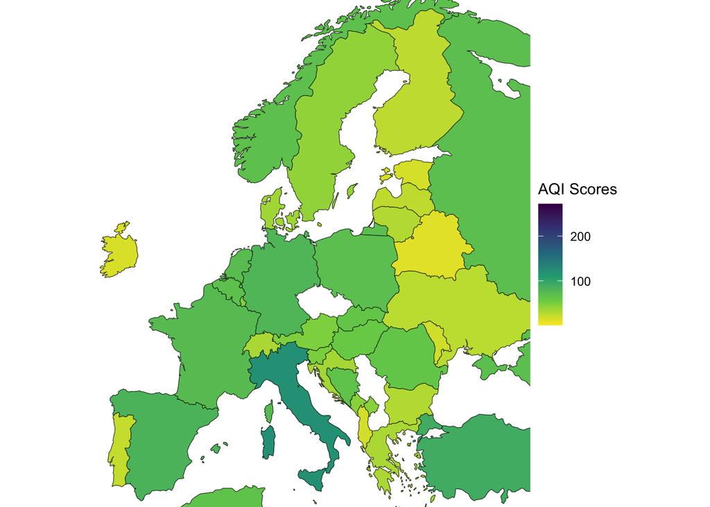

Figure 2: Map of AQI Scores in Europe